# Geog533 Lab 7 - Correlation

Your name

## Question 1

This is Exercise 1 in Chapter 7 of the Textbook [R].

### Problem 1a

Find the correlation coefficient, *r*, for the following sample data on income and education:

```r
library(knitr)
obs <- seq(1:5)
income <- c(30,28,52,40,35)
edu <- c(12,13,18,16,17)
df <- data.frame(obs,income,edu)
names(df) <- c("Observation","Income ($*1000)","Education (Years)")
kable(df)
```

| Observation | Income ($*1000) | Education (Years) |
| --- | --- | --- |
| 1 | 30 | 12 |
| 2 | 28 | 13 |
| 3 | 52 | 18 |
| 4 | 40 | 16 |
| 5 | 35 | 17 |

Solution 1a

```r
cor(income, edu, method = "pearson")
```

```
[1] 0.83577
```

### Problem 1b

Solution 1b

```r
if(cor.test(income, edu, method = "pearson")[3]$p.value > 0.05)
{
  print('Income is not related to education')

}
```

```
[1] "Income is not related to education"
```

### Problem 1c

Find Spearman鈥檚 rank correlation coefficient for these data.

Solution 1c

```r
cor(income, edu, method = "spearman")
```

```
[1] 0.8
```

### Problem 1d

Test whether the observed value of rs from part (c) is significantly different from zero.

Solution 1d

```r
result <- cor.test(income, edu, method = "spearman",alternative = 'greater')
if (result[3]$p.value > 0.05)
{  print('Income is not related to education')
  }
```

```
[1] "Income is not related to education"
```

## Question 2

This is Exercise 3 in Chapter 7 of the Textbook [R].

### Solution

```r
t.36 <- qt(0.975, df = 34)
r.36 <- sqrt(t.36^2/(34 + t.36^2))
t.80 <- qt(0.975, df = 78)
r.80 <- sqrt(t.80^2/(78 + t.80^2))
print(paste("when the sample size is 36,The smallest absolute value is",round(r.36, digits = 3)))
```

```
[1] "when the sample size is 36,The smallest absolute value is 0.329"
```

```r
print(paste("when the sample size is 80,The smallest absolute value is",round(r.80, digits = 3)))
```

```
[1] "when the sample size is 80,The smallest absolute value is 0.22"
```

## Question 3

This is Exercise 4 in Chapter 7 of the Textbook [R].

### Problem

Find the correlation coefficient for the following data:

```r
library(knitr)
Obs <- seq(1:4)
X <- c(2,8,9,7)
Y <- c(6,6,10,4)
df <- data.frame(Obs,X,Y)
kable(df)
```

| Obs | X | Y |
| --- | --- | --- |
| 1 | 2 | 6 |
| 2 | 8 | 6 |
| 3 | 9 | 10 |
| 4 | 7 | 4 |

### Solution

```r
cor(X,Y,method = 'pearson')
```

```
[1] 0.3834129
```

## Question 4

This is Exercise 6 in Chapter 7 of the Textbook [R].

### Problem

```r
year <- 1984:1994
income <- c(35165,35778,37027,37256,37512,37997,37343,36054,35593,35241,35486)
races <- c(399,469,429,450,474,598,364,430,433,410,317)
df <- data.frame(year,income,races)
names(df) <- c("Year","Median income","Number of races won by leading jockey")
kable(df)
```

| Year | Median income | Number of races won by leading jockey |
| --- | --- | --- |
| 1984 | 35165 | 399 |
| 1985 | 35778 | 469 |
| 1986 | 37027 | 429 |
| 1987 | 37256 | 450 |
| 1988 | 37512 | 474 |
| 1989 | 37997 | 598 |
| 1990 | 37343 | 364 |
| 1991 | 36054 | 430 |
| 1992 | 35593 | 433 |
| 1993 | 35241 | 410 |
| 1994 | 35486 | 317 |

### Solution

```r
if(cor.test(income,races,method = 'pearson')[3]$p.value > 0.05)
{
  print('Number of races won by leading jockey is not related to Median income')
}
```

```
[1] "Number of races won by leading jockey is not related to Median income"
```

## Question 5

This is Exercise 7 in Chapter 7 of the Textbook [R].

### Problem

For the following ranked data, find Spearman鈥檚 r, and then test the null hypothesis (using a Type I error probability of 0.10) that the true correlation is equal to zero.

```r
library(knitr)
obs <- 1:6
x <- c(1,2,5,6,11,12)
y <- c(8,4,12,3,10,7)
df <- data.frame(obs,x,y)
names(df) <- c("Observation","Rank of x","Rank of y")
kable(df)
```

| Observation | Rank of x | Rank of y |
| --- | --- | --- |
| 1 | 1 | 8 |
| 2 | 2 | 4 |
| 3 | 5 | 12 |
| 4 | 6 | 3 |
| 5 | 11 | 10 |
| 6 | 12 | 7 |

### Solution

```r
cor(x,y,method = 'spearman')
```

```
[1] -0.02857143
```

```r
result_new <- cor.test(x,y,method = 'spearman')[3]
if(result_new$p.value > 0.10 )
{
  print('there is no relationship between x and y')
}
```

```
[1] "there is no relationship between x and y"
```

## Question 6

This is Exercise 8 in Chapter 7 of the Textbook [R].

### Problem

Find Pearson鈥檚 r for the following data, and then test the null hypothesis that the correlation coefficient is equal to zero. Use a Type I error probability of 0.05.

```r
library(knitr)
obs <- 1:6
x <- c(3.2,2.4,1.6,8.3,7.2,5.1)
y <- c(6.2,7.3,8.1,2.6,6.3,4.3)
df <- data.frame(obs,x,y)
names(df) <- c("Observation","x","y")
kable(df)
```

| Observation | x | y |
| --- | --- | --- |
| 1 | 3.2 | 6.2 |
| 2 | 2.4 | 7.3 |
| 3 | 1.6 | 8.1 |
| 4 | 8.3 | 2.6 |
| 5 | 7.2 | 6.3 |
| 6 | 5.1 | 4.3 |

### Solution

```r
cor(x,y,method = 'pearson')
```

```
[1] -0.8073491
```

```r
if(cor.test(x,y,method = 'pearson')[3]$p.value > 0.05)
{
  print('there is no relationship between x and y')
}
```

```
[1] "there is no relationship between x and y"
```

## Question 7

This is Exercise 9 in Chapter 7 of the Textbook [R].

### Problem

Using R and the Milwaukee dataset, find the correlation between number of bedrooms and lot size.

### Solution

```r
table <- read.csv(file = 'Table.csv')
size <- table$Lotsize
bedroom <- table $Nr_of_rms
cor <- cor(size, bedroom, use = "everything", method = c("pearson", "kendall", "spearman"))
print(paste("The correlation between size and bedrooms is",round(as.numeric(cor),digits = 3)))
```

```
[1] "The correlation between size and bedrooms is -0.109"
```

## Question 8

This is Exercise 10 in Chapter 7 of the Textbook [R].

### Problem

Using R and the Hypothetical UK Housing Prices dataset, find the correlation between floor area and number of bedrooms.

### Solution

```r
uk <- read.csv(file = "UK.csv")
cor <- cor(uk$bedrooms, uk$floorarea, use = "everything", method = c("pearson", "kendall", "spearman"))
print(paste("The correlation between floor and bedrooms is",round(as.numeric(cor),digits = 3)))
```

```
[1] "The correlation between floor and bedrooms is 0.611"
```

## Question 9

Use the **cars** data frame in the **datasets** package to perform the following tasks:

### Problem 9a

Plot a scatterplot for the data frame (x: speed, y: dist)

Solution 9a

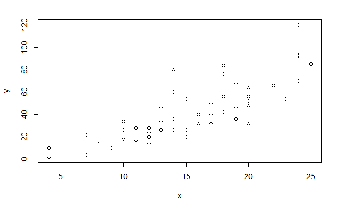

```r
df_new <- cars
x <- df_new$speed
y <- df_new$dist
plot(x,y)
```

### Problem 9b

How many rows in the data frame?

Solution 9b

```r
nrow(df_new)
```

```
[1] 50
```

### Problem 9c

Calculate Pearson鈥檚 correlation coefficient using the equation below:
$$r=\frac{\sum_{n}^{i=1}(x_i-\bar{x})(y_i-\bar{y})}{(n-1)s_{x}s_{y}}$$

Solution 9c

```r
s <- sum((x - mean(x))*(y - mean(y)))/49
r <- s/(sd(x)*sd(y))
r
```

```
[1] 0.8068949
```

### Problem 9d

Use the cor.test() function to find Pearson鈥檚 correlation coefficient and compare it to the one from part (c)

Solution 9d

```r
m <- cor.test(x,y,method = 'pearson')
as.numeric(m[4]$estimate[1])
```

```
[1] 0.8068949
```

```r
print('They are same')
```

```
[1] "They are same"
```

### Problem 9e

Calculate Spearman鈥檚 rank correlation coefficient using the equation below:
$$r_{S} = 1 - \frac{6\sum_{i=1}^{n}d_{i}^{2}}{n^3-n}$$

Solution 9e

```r
df_new$rankspeed <- rank(df_new$speed)
df_new$rankdist <- rank(df_new$dist)
d <- df_new$rankspeed - df_new$rankdist
rs <- 1 - sum(d * d)*6/(50*50*50 - 50)
rs
```

```
[1] 0.8308283
```

### Problem 9f

Use the cor.test() function to find Spearman鈥檚 rank correlation coefficient and compare it to the one from part (e)

Solution 9f

```r
result <- cor.test(df_new$speed,df_new$dist,alternative = 'greater',method = 'spearman')
as.numeric(result[4]$estimate) - rs
```

```
[1] -0.0004714925
```

```r
print('They are approximately same')
```

```
[1] "They are approximately same"
```